# MLI1-2009

Author

Grasland C.

## Fonds de carte

On utilise le découpage de premier niveau du pays.

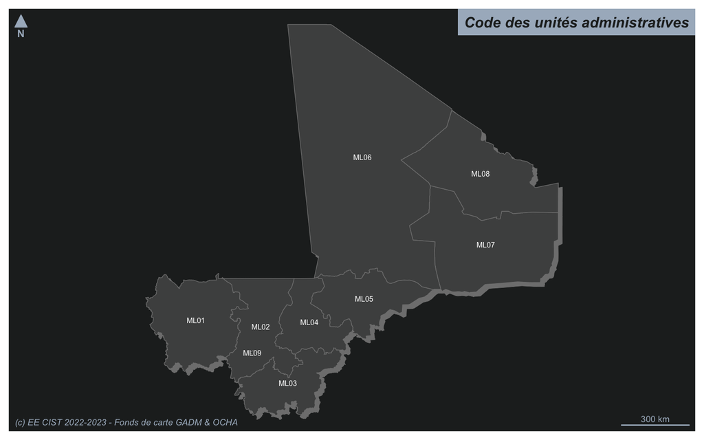

## Matrice de migration totale

On extrait la matrice de migration totale puis on calcule pour chaque paire de régions le solde et le volume des échanges.

```
# A tibble: 6 × 12
# Groups:   i [1]
  i     j     Ni    Nj       Fij   Fji  FVij  FSij      Xi     Yi      Xj     Yj
  <chr> <chr> <chr> <chr>  <dbl> <dbl> <dbl> <dbl>   <dbl>  <dbl>   <dbl>  <dbl>
1 ML01  ML02  Kayes Kouli… 29450 32960 62410  3510 -1.14e6 1.56e6 -8.51e5 1.53e6
2 ML01  ML03  Kayes Sikas…  8930 10770 19700  1840 -1.14e6 1.56e6 -7.30e5 1.28e6
3 ML01  ML04  Kayes Ségou   8050 13920 21970  5870 -1.14e6 1.56e6 -6.34e5 1.55e6
4 ML01  ML05  Kayes Mopti   2000  6760  8760  4760 -1.14e6 1.56e6 -3.91e5 1.66e6
5 ML01  ML06  Kayes Timbu…   550  1230  1780   680 -1.14e6 1.56e6 -3.98e5 2.29e6
6 ML01  ML07  Kayes Gao      400  1350  1750   950 -1.14e6 1.56e6  1.50e5 1.90e6
```

```
      i                  j                  Ni                 Nj
 Length:90          Length:90          Length:90          Length:90
 Class :character   Class :character   Class :character   Class :character
 Mode  :character   Mode  :character   Mode  :character   Mode  :character




      Fij                Fji                FVij             FSij
 Min.   :    30.0   Min.   :    30.0   Min.   :   100   Min.   :-126580
 1st Qu.:   402.5   1st Qu.:   402.5   1st Qu.:   850   1st Qu.:  -2605
 Median :  2160.0   Median :  2160.0   Median :  5780   Median :      0
 Mean   : 15147.1   Mean   : 15147.1   Mean   : 30294   Mean   :      0
 3rd Qu.: 14780.0   3rd Qu.: 14780.0   3rd Qu.: 35280   3rd Qu.:   2605
 Max.   :157280.0   Max.   :157280.0   Max.   :268970   Max.   : 126580

       Xi                 Yi                Xj                 Yj
 Min.   :-1138864   Min.   :1281438   Min.   :-1138864   Min.   :1281438
 1st Qu.: -851040   1st Qu.:1532215   1st Qu.: -851040   1st Qu.:1532215
 Median : -634327   Median :1560252   Median : -634327   Median :1560252
 Mean   : -528309   Mean   :1710423   Mean   : -528309   Mean   :1710423
 3rd Qu.: -390851   3rd Qu.:1897525   3rd Qu.: -390851   3rd Qu.:1897525
 Max.   :  149958   Max.   :2286799   Max.   :  149958   Max.   :2286799
 NA's   :9          NA's   :9         NA's   :9          NA's   :9
```

### Volume

On représente les volumes de flux dont la valeur est supérieure à la moyenne .

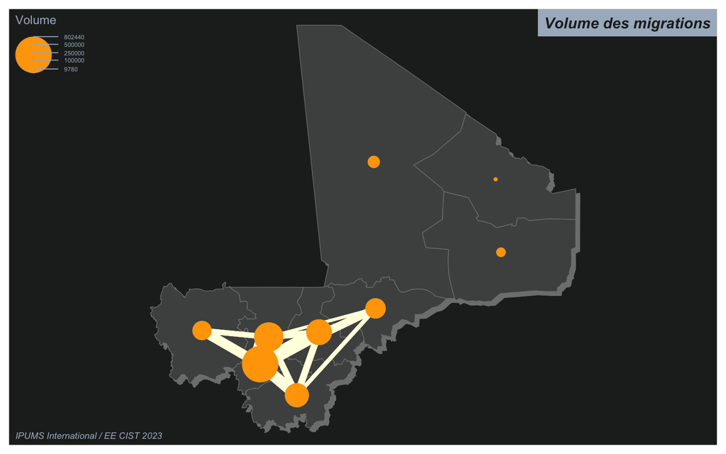

### Solde

On représente les soldes de flux dont la valeur est supérieure à la moyenne .

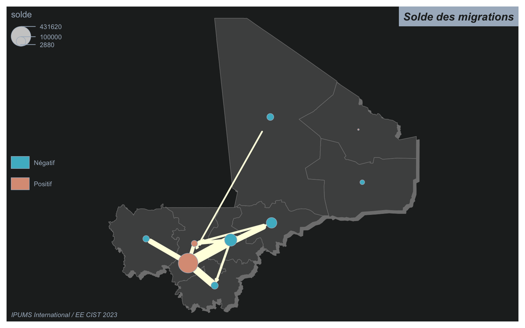

### Flux dominant

On détermine pour chaque unité spatiale son flux le plus important vers une autre unité spatiale. On considère qu’une unité est de type :

- **dominante** si son nombre si son nombre d’arrivée est supérieur à l’unité vers laquelle elle envoie son plus grand flux.
- **dominée** si son nombre d’arrivée est inférieur à l’unité vers laquelle elle envoie son plus grand flux.
- **relais** si elle est à la fois dominée et dominante.

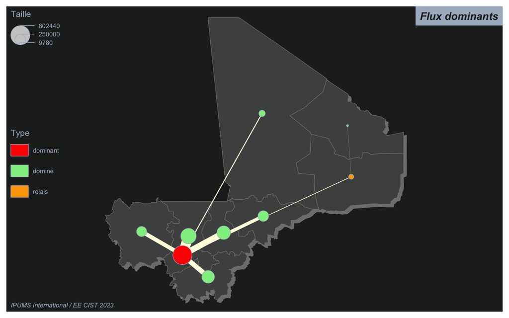